# HW2

Jiseon Yang

2024-10-01

## 1.

```r
# Define the matrix
A <- matrix(c(1, 0, 0, 0,
              -1, 1, 0, 0,
              0, -1, 1, 0,
              0, 0, -1, 1,
              0, 0, 0, -1),
            nrow = 5, ncol = 4, byrow = TRUE)

library(pracma)

# Gram-Schmidt process
Q <- gramSchmidt(A)$Q

# Output the orthonormal matrix
gramSchmidt(Q)
```

```
## $Q
##            [,1]       [,2]       [,3]       [,4]
## [1,]  0.7071068  0.4082483  0.2886751  0.2236068
## [2,] -0.7071068  0.4082483  0.2886751  0.2236068
## [3,]  0.0000000 -0.8164966  0.2886751  0.2236068
## [4,]  0.0000000  0.0000000 -0.8660254  0.2236068
## [5,]  0.0000000  0.0000000  0.0000000 -0.8944272
##
## $R
##      [,1]          [,2]          [,3]          [,4]
## [1,]    1 -1.110223e-16 -1.110223e-16 -1.110223e-16
## [2,]    0  1.000000e+00  1.110223e-16  1.110223e-16
## [3,]    0  0.000000e+00  1.000000e+00  8.326673e-17
## [4,]    0  0.000000e+00  0.000000e+00  1.000000e+00
```

## 2 (a) Profile plot

• WI (Weights Increasing): The trend appears to be mostly linear but could have a slight quadratic component due to the accelerating increase in later weeks. • RI (Repetitions Increasing): A quadratic trend is likely, with an increase followed by a leveling off of strength. • CONT (Control): A flat or slightly negative linear trend, indicating no major polynomial trend.

```r
# Load necessary libraries
library(dplyr)
```

```r
library(ggplot2)
#install.packages("tidyr")
library(tidyr)
library(reshape2)
# Load the data
strength_wide <- read.table("C:/Users/jyang/OneDrive - Arizona State University/10 Classes_OneDrive/2024 8F_STP598_Logitudinal/zz HW/Longitudinal_HW2/strength.dat", header = FALSE)

# Add proper column names for better understanding
names(strength_wide) <- c("ID", "Group", "Week1", "Week2", "Week3", "Week4", "Week5", "Week6", "Week7")

# Convert data from wide format to long format
strength_long <- melt(strength_wide, id.vars = c("ID", "Group"),
                      variable.name = "Week", value.name = "Strength")

# Convert 'Week' to a numeric variable (removing 'Week' prefix)
strength_long$Week <- as.numeric(gsub("Week", "", strength_long$Week))

length(unique(strength_long$ID))
```

```
## [1] 21
```

```r
table(strength_wide$Group)
```

```
##
## CONT   RI   WI
##   20   16   21
```

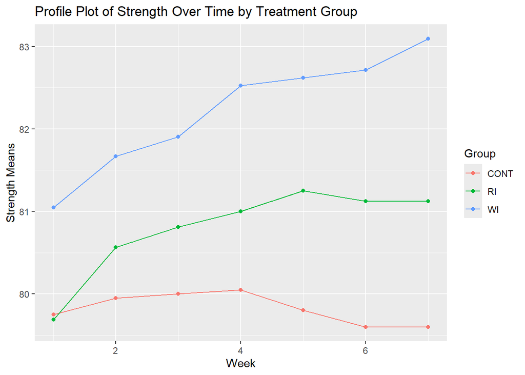

```r
# Generate the plot
strength_long %>%
  group_by(Group, Week) %>%
  summarise(Strength = mean(Strength, na.rm = TRUE), .groups = "drop") %>%
  ggplot(aes(x = Week, y = Strength, color = as.factor(Group))) +
  geom_point() +
  geom_line() +
  ylab("Strength Means") +
  scale_color_discrete(name = "Group") +
  ggtitle("Profile Plot of Strength Over Time by Treatment Group") +
  xlab("Week")
```

## 2 (c) Fit the Split-Plot Model: ANOVA approach -. use aov() function -. best suit for banlanced model (not for unbalanced model) -. contrast function